# Analysis of postural sway data

Author

Steve Simon

Published

October 7, 2024

This program reads data and runs a two-sample t-test. Consult the [data dictionary](https://github.com/pmean/data/blob/main/files/postural-sway.yaml) for information about the data itself.

This program was written by Steve Simon on 2024-10-07. It is placed in the public domain.

# — Part 1: Analysis of front-to-back sway

## Models

- m1: Comparison of fb_sway by age groups using t.test function
- m2: Equivalent analysis using lm function

## Libraries

```r
library(broom)
library(tidyverse)
```

## Read data

```r
sway <- read_tsv(
  file="../data/postural-sway.txt",
  col_types="cnn")
names(sway) <- tolower(names(sway))
glimpse(sway)
```

```
Rows: 17
Columns: 3
$ age      <chr> "Elderly", "Elderly", "Elderly", "Elderly", "Elderly", "Elder…
$ fbsway   <dbl> 19, 30, 20, 19, 29, 25, 21, 24, 50, 25, 21, 17, 15, 14, 14, 2…
$ sidesway <dbl> 14, 41, 18, 11, 16, 24, 18, 21, 37, 17, 10, 16, 22, 12, 14, 1…
```

## Boxplot of front-to-back sway by age

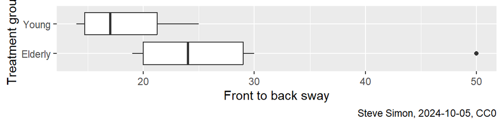

```r
sway |>
  ggplot() +
  aes(fbsway, age) +
  geom_boxplot() +
  labs(
    caption="Steve Simon, 2024-10-05, CC0",
    x="Front to back sway",
    y="Treatment group")
```

#### Interpretation of the output

The elderly patients have generally higher sway values. Both groups have similar variation except for an extreme outlier in the elderly patients.

## Descriptive statistics for front-to-back sway by age

```r
sway |>
  group_by(age) |>
  summarize(
    fb_mn=mean(fbsway),
    fb_sd=sd(fbsway),
    n=n())
```

```
# A tibble: 2 × 4
  age     fb_mn fb_sd     n
  <chr>   <dbl> <dbl> <int>
1 Elderly  26.3  9.77     9
2 Young    18.1  4.09     8
```

## Two-sample t-test

```r
m1 <- t.test(
  fbsway ~ age,
  data=sway,
  alternative="two.sided",
  var.equal=TRUE)
m1
```

```
    Two Sample t-test

data:  fbsway by age
t = 2.2044, df = 15, p-value = 0.04353
alternative hypothesis: true difference in means between group Elderly and group Young is not equal to 0
95 percent confidence interval:
  0.2715453 16.1451214
sample estimates:
mean in group Elderly   mean in group Young
             26.33333              18.12500
```

#### Comments on the code

The [t.test function](https://stat.ethz.ch/R-manual/R-devel/library/stats/html/t.test.html) is part of the base R package. You use a formula identical to the formula used in the lm function. The dependent or outcome variable goes to the left of the tilde and the binary category goes on the right. The alternative argument is “two.sided” for a two-sided test. Use “less” to test the one sided hypothesis H1: mu1 <- m2 and “greater” to test the hypothesis H1: mu1 > mu2.

#### Interpretation of the output

The t-statistic is quite different from zero, the p-value is small and the confidence interval excludes the value of zero. Conclude that there is a larger average front-to-back sway in the elderly group. The confidence interval, however, is quite wide, indicating that you do not have a very precise estimate of how much worse the elderly group is. It could be as small as 0.3 millimeters and as large as 16 millimeters.

## Equivalent analysis using linear regression

```r
m2 <- lm(fbsway ~ age, data=sway)
tidy(m2)
```

```
# A tibble: 2 × 5
  term        estimate std.error statistic      p.value
  <chr>          <dbl>     <dbl>     <dbl>        <dbl>
1 (Intercept)    26.3       2.55     10.3  0.0000000334
2 ageYoung       -8.21      3.72     -2.20 0.0435
```

```r
confint(m2)
```

```
                2.5 %     97.5 %
(Intercept)  20.88874 31.7779250
ageYoung    -16.14512 -0.2715453
```

#### Interpretation of the output

The interpretation is identical. Note, however, that the estimated difference and the confidence limits are negative. This is caused by R using an indicator equal to 1 for the last category in alphabetical order (Young).

# — Part 2: Power calculations for two scenarios

## Scenario 1

- Replicate postural sway study
  - Different populations
  - Same outcome measure
- Research hypothesis, $H_0\ \mu_1 - \mu_2 = 0$
- Standard deviations: 9.77, 4.09
- MCID = 4

```r
power.t.test(
  n=NULL,
  delta=4,
  sd=9.8,
  sig.level=0.05,
  power=0.9,
  type="two.sample",
  alternative="two.sided")
```

```
     Two-sample t test power calculation

              n = 127.1097
          delta = 4
             sd = 9.8
      sig.level = 0.05
          power = 0.9
    alternative = two.sided

NOTE: n is number in *each* group
```

## Scenario 2, Reduce the MCID from 4 to 2

```r
power.t.test(
  n=NULL,
  delta=2,
  sd=9.8,
  sig.level=0.05,
  power=0.9,
  type="two.sample",
  alternative="two.sided")
```

```
     Two-sample t test power calculation

              n = 505.5288
          delta = 2
             sd = 9.8
      sig.level = 0.05
          power = 0.9
    alternative = two.sided

NOTE: n is number in *each* group
```

#### Interpretation of the output

If we wanted to be able to detect a 2 millimeter difference instead of a 4 millimeter difference, you would need a sample size that is about four times as large.